# Estimating Non Linear Threshold for Selected Brands by Least Square Method

We import Ramlosa at Supermarket datasets that has statistical evidence for “historical price gap”

```r
library(dplyr) #for mutate factor
library(data.table) #turning results in table
```

```r
df_his <- read.csv("../../../../src/analysis/nonlinear_byformat/price threshold/ramlosa_super_histgap.csv")
df_his <- df_his %>% mutate(vecka=droplevels(as.factor(vecka)))

df_full <- read.csv("../../../../src/analysis/nonlinear_byformat/price threshold/loka_super_fullgap.csv")
df_full <- df_full %>% mutate(vecka=droplevels(as.factor(vecka)))
```

Model Free Evidence Between Price and Sales

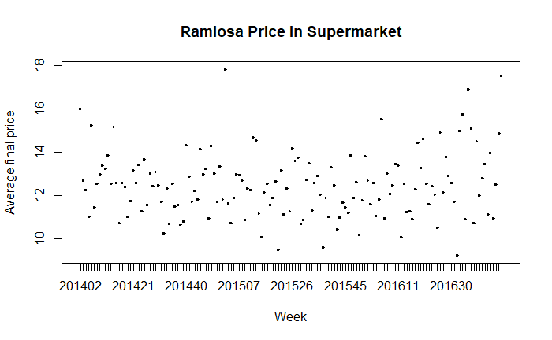

```r
plot(df_his$vecka, df_his$avgfinalprice, main = "Ramlosa Price in Supermarket", xlab = "Week", ylab = "Average final price", col="blue")
```

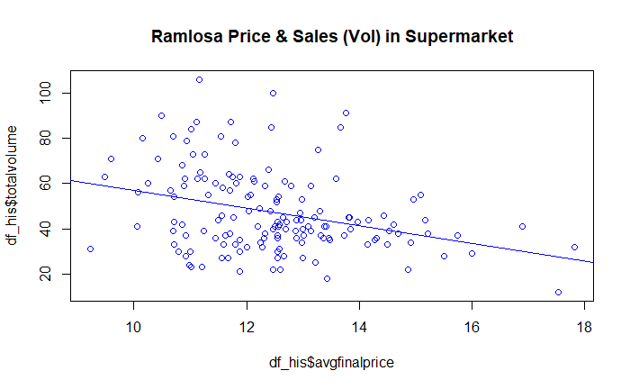

```r
plot(df_his$totalvolume ~ df_his$avgfinalprice, main = "Ramlosa Price & Sales (Vol) in Supermarket", col="blue")
abline(lm(df_his$totalvolume ~ df_his$avgfinalprice), col="blue")
```

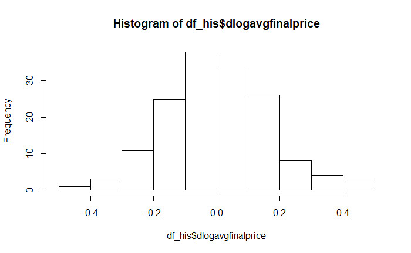

```r
hist(df_his$dlogavgfinalprice)
```

```r
summary(df_his$dlogavgfinalprice)
```

```
     Min.   1st Qu.    Median      Mean   3rd Qu.      Max.
-0.427536 -0.105955 -0.005300  0.001199  0.106746  0.484274
```

1. Simple Model to calculate error (correction) term:
   $$(1) ln(S_{i,t-1}) = a_{0i}+a_{1i}ln(P_{it-1}) +
   e_{it}$$
2. Calculate Linear Model to get initial value for optimization
   $$\Delta ln(S_{i,t}) =
   \beta_{0i}+\beta_{1i}\Delta (P_{it})+ \phi_1[ln(S_{i,t-1})-\phi_2
   ln(P_{i,t-1}))]$$

```r
lm_his_linear <- lm(dlogtotalvolume ~ dlogavgfinalprice + log(totalvolume1) + log(avgfinalprice1) ,data=df_his)

summary(lm_his_linear)
```

```
Call:
lm(formula = dlogtotalvolume ~ dlogavgfinalprice + log(totalvolume1) +
    log(avgfinalprice1), data = df_his)

Residuals:
    Min      1Q  Median      3Q     Max
-0.9247 -0.2085  0.0180  0.2290  0.8168

Coefficients:
                    Estimate Std. Error t value Pr(>|t|)
(Intercept)          5.34979    1.02941   5.197 6.61e-07 ***
dlogavgfinalprice   -1.03702    0.24608  -4.214 4.34e-05 ***
log(totalvolume1)   -0.90440    0.08357 -10.822  < 2e-16 ***
log(avgfinalprice1) -0.76489    0.36334  -2.105    0.037 *
---
Signif. codes:  0 ‘***’ 0.001 ‘**’ 0.01 ‘*’ 0.05 ‘.’ 0.1 ‘ ’ 1

Residual standard error: 0.3564 on 148 degrees of freedom
Multiple R-squared:  0.5093,    Adjusted R-squared:  0.4994
F-statistic: 51.21 on 3 and 148 DF,  p-value: < 2.2e-16
```

```r
c_his_lm <- summary(lm_his_linear)$coefficients[1,1]
alpha_0_his_lm <- summary(lm_his_linear)$coefficients[2,1]
phi_1_his_lm <- summary(lm_his_linear)$coefficients[3,1]
phi_2_his_lm <- (summary(lm_his_linear)$coefficients[4,1])/(summary(lm_his_linear)$coefficients[3,1]) # this coef = phi1*phi2

paste("Initial Value for constant term:", c_his_lm)
```

```
[1] "Initial Value for constant term: 5.34978665959991"
```

```r
paste("Initial Value for base elasticity:", alpha_0_his_lm)
```

```
[1] "Initial Value for base elasticity: -1.03701666156366"
```

```r
paste("Initial Value for phi1:", phi_1_his_lm)
```

```
[1] "Initial Value for phi1: -0.904403840564525"
```

```r
paste("Initial Value for phi2:", phi_2_his_lm) #should be positive?
```

```
[1] "Initial Value for phi2: 0.845736530191863"
```

Objective: We want to estimate nonlinear model with historical price gap:
$$\Delta ln(S_{i,t}) = c +\{\alpha_{0}
+ \frac{\alpha_{HG}}{1+exp(\gamma(HistPGap_{i,t}))-b_{HG})}
+\frac{\alpha_{HL}}{1+exp(-\gamma(HistPGap_{i,t}))-b_{HL})}\}\Delta
ln(P_{i,t})\\
+ \phi_1[ln(S_{i,t-1})+\phi_2 ln(P_{i,t-1}))]$$

We will obtain initial value of thresholds ($\beta_G,\beta_L$) from distribution of $\Delta (P_{it}$ and change of slope by moderate change ($\alpha_G,\alpha_L$) and assume symmetrical case.

```r
alpha_g_his_lm <- -0.25
alpha_l_his_lm <- 0.25

beta_l_his_lm <- mean(df_his$dlogavgfinalprice) + sd(df_his$dlogavgfinalprice)
beta_g_his_lm <- -beta_l_his_lm

paste("Initial Value for change slope gain (alphaG):", alpha_g_his_lm)
```

```
[1] "Initial Value for change slope gain (alphaG): -0.25"
```

```r
paste("Initial Value for change slope loss (alphaL):", alpha_l_his_lm)
```

```
[1] "Initial Value for change slope loss (alphaL): 0.25"
```

```r
paste("Initial Value for threshold gain (betaG):", beta_g_his_lm)
```

```
[1] "Initial Value for threshold gain (betaG): -0.167448539181518"
```

```r
paste("Initial Value for threshold loss (betaL):", beta_l_his_lm) #should be positive?
```

```
[1] "Initial Value for threshold loss (betaL): 0.167448539181518"
```

Then, we estimate using least square method (minimizing SSE)

```r
LS_nonlinear_his <- function(parvec){

  F_H_G <- 1/(1+exp(gamma*(df_his$hgap - parvec[4])))
  F_H_L <- 1/(1+exp(-gamma*(df_his$hgap - parvec[6])))


  ut <- df_his$dlogtotalvolume - (parvec[1] + (parvec[2]
                                         + parvec[3]*F_H_G + parvec[5]*F_H_L)*df_his$dlogavgfinalprice
                            + parvec[7]*((log(df_his$totalvolume1))+parvec[8]*log(df_his$avgfinalprice1)))
  SSE <- sum(ut^2)
  return(SSE)
}

  gamma <- 500 #assumed

  parvec_1 <- c_his_lm
  parvec_2 <- alpha_0_his_lm
  parvec_3 <- alpha_g_his_lm
  parvec_4 <- beta_g_his_lm
  parvec_5 <- alpha_l_his_lm
  parvec_6 <-  beta_l_his_lm
  parvec_7 <- phi_1_his_lm
  parvec_8 <- phi_2_his_lm


Start_v_LS <- c(parvec_1,parvec_2,parvec_3,parvec_4,parvec_5,parvec_6,parvec_7,parvec_8)

  n <- dim(df_his)[1]
  k <- length(Start_v_LS)


LS_logL_nonlinear_his_constraint = optim(Start_v_LS,
                  fn = LS_nonlinear_his, # function to maximize
                  method = "BFGS",
                  control = list(fnscale = 1), # minimize the function
                  hessian = T # calculate Hessian matrix because we will need for confidence intervals
                  )

MSE_calculated <- LS_logL_nonlinear_his_constraint$value/(n-k)

paste("Calculated SE of model:",MSE_calculated)
```

```
[1] "Calculated SE of model: 0.126189294661364"
```

```r
par_LS.est<-LS_logL_nonlinear_his_constraint$par
OI<-solve(LS_logL_nonlinear_his_constraint$hessian)
par_LS.se<-sqrt(diag(OI))

Start_v_LS
```

```
[1]  5.3497867 -1.0370167 -0.2500000 -0.1674485  0.2500000  0.1674485 -0.9044038  0.8457365
```

```r
par_LS.est
```

```
[1]  5.2216815 -1.2536854  0.9075398 -0.3200971  0.8244547  0.3758996 -0.9023296  0.7938632
```

```r
par_LS_name <- c("constant", "price_elas" ,"hgap_gain_slope","hgap_gain_threshold","hgap_loss_slope","hgap_loss_threshold",
                   "correction_1","correction_2")
par_LS <- data.table(cbind(par_LS_name,par_LS.est,par_LS.se))
par_LS$tstat <- as.numeric(par_LS$par_LS.est)/as.numeric(par_LS$par_LS.se)

par_LS
```

| par_LS_name | par_LS.est | par_LS.se | tstat |
| --- | --- | --- | --- |
| constant | 5.22168154098431 | 2.07268641606915 | 2.51928198 |
| price_elas | -1.25368536065622 | 0.530285349388908 | -2.36417122 |
| hgap_gain_slope | 0.907539832584184 | 1.05624102157726 | 0.85921661 |
| hgap_gain_threshold | -0.32009707412735 | 1.42244334079067 | -0.22503327 |
| hgap_loss_slope | 0.82445470130232 | 1.01302094647546 | 0.81385751 |
| hgap_loss_threshold | 0.37589960611375 | 9.676158291573 | 0.03884802 |
| correction_1 | -0.90232955733027 | 0.165856011764113 | -5.44043926 |
| correction_2 | 0.793863218868694 | 0.795834667314552 | 0.99752279 |

Plot

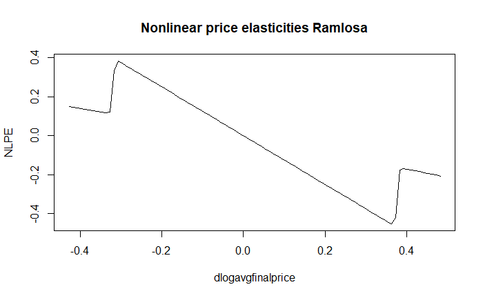

```r
c_0 <- par_LS.est[1]
alpha0 <- par_LS.est[2]
alpha_G <- par_LS.est[3]
beta_G <- par_LS.est[4]
alpha_L <- par_LS.est[5]
beta_L <- par_LS.est[6]
phi_1_his <- par_LS.est[7]
phi_2_his <- par_LS.est[8]

# Defining x-values
graph_reso <- 0.01
x_values <- seq(min(df_his$dlogavgfinalprice), max(df_his$dlogavgfinalprice), by = graph_reso)
xgap_values <- seq(min(df_his$hgap), max(df_his$hgap), by = graph_reso)


# Defining various functions to plot
NLPE <- function(dlogavgfinalprice,hgap)
      {( alpha0 + alpha_G*( 1 + exp(gamma*(hgap-beta_G) ) )^-1 + alpha_L*( 1 + exp(-gamma*(hgap-beta_L) ) )^-1 )*dlogavgfinalprice}
TransF <- function(hgap){alpha0 + alpha_G*( 1 + exp(gamma*(hgap-beta_G) ) )^-1 + alpha_L*( 1 + exp(-gamma*(hgap-beta_L)))^-1}

F_G <- function(x){( 1 + exp( gamma*(hgap-beta_G) ) )^-1}
F_L <- function(x){( 1 + exp( -gamma*(hgap-beta_L) ) )^-1}

NLPE_values <- NLPE(dlogavgfinalprice=x_values,hgap=xgap_values)
TransF_values <- TransF(hgap=xgap_values)
time <- seq(1:151)

#Plot
plot(x_values, NLPE_values, type = "l", main = "Nonlinear price elasticities Ramlosa", xlab = "dlogavgfinalprice", ylab = "NLPE")
```

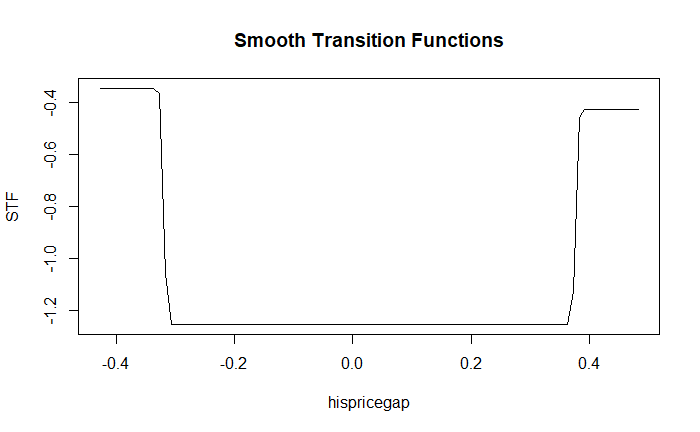

```r
plot(xgap_values, TransF_values, type = "l", main = "Smooth Transition Functions", xlab = "hispricegap", ylab = "STF")
```

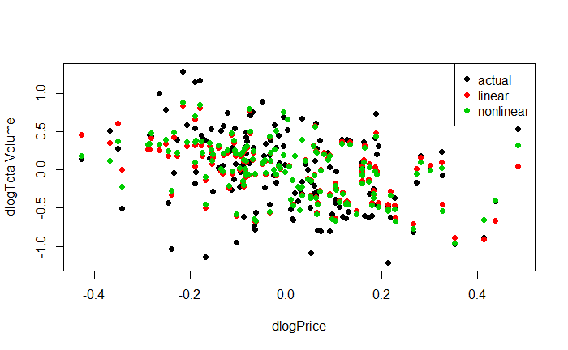

```r
linear_predict <- function(dlogavgfinalprice,totalvolume1,avgfinalprice1){
  c_his_lm + alpha_0_his_lm*dlogavgfinalprice + phi_1_his_lm*log(totalvolume1) + (phi_1_his_lm*phi_2_his_lm)*log(avgfinalprice1)
  }

nonlinear_predict <- function(dlogavgfinalprice,hgap,totalvolume1,avgfinalprice1)
{c_0 +(alpha0 + alpha_G*( 1 + exp(gamma*(hgap-beta_G) ) )^-1 + alpha_L*( 1 + exp(-gamma*(hgap-beta_L) ) )^-1 )*dlogavgfinalprice + phi_1_his*(log(df_his$totalvolume1))+(phi_1_his*phi_2_his*log(df_his$avgfinalprice1))}

pre_linear <- cbind(linear_predict(dlogavgfinalprice=df_his$dlogavgfinalprice,totalvolume1 = df_his$totalvolume1,avgfinalprice1 = df_his$avgfinalprice1),df_his$dlogavgfinalprice,c("linear"))

pre_nonlinear<- cbind(nonlinear_predict(dlogavgfinalprice=df_his$dlogavgfinalprice,hgap=df_his$dlogavgfinalprice,totalvolume1 = df_his$totalvolume1,avgfinalprice1 = df_his$avgfinalprice1),df_his$dlogavgfinalprice,c("nonlinear"))

actual <- cbind(df_his$dlogtotalvolume,df_his$dlogavgfinalprice,c("actual"))

compare_actual_predict <- rbind(actual,pre_linear,pre_nonlinear)


plot(compare_actual_predict[,2], compare_actual_predict[,1], pch = 19,col = factor(compare_actual_predict[,3]),
     xlab="dlogPrice", ylab="dlogTotalVolume")
legend("topright",
       legend = levels(factor(compare_actual_predict[,3])),
       pch = 19,
       col = factor(levels(factor(compare_actual_predict[,3]))))
```

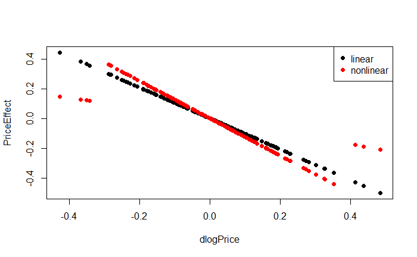

```r
linear_predict <- function(dlogavgfinalprice){alpha_0_his_lm*dlogavgfinalprice}

nonlinear_predict <- function(dlogavgfinalprice,hgap)
{(alpha0 + alpha_G*( 1 + exp(gamma*(hgap-beta_G) ) )^-1 + alpha_L*( 1 + exp(-gamma*(hgap-beta_L) ) )^-1 )*dlogavgfinalprice}

pre_linear <- cbind(linear_predict(dlogavgfinalprice=df_his$dlogavgfinalprice),df_his$dlogavgfinalprice,c("linear"))

pre_nonlinear<- cbind(nonlinear_predict(dlogavgfinalprice=df_his$dlogavgfinalprice,hgap=df_his$dlogavgfinalprice),df_his$dlogavgfinalprice,c("nonlinear"))


compare_actual_predict <- rbind(pre_linear,pre_nonlinear)


plot(compare_actual_predict[,2], compare_actual_predict[,1], pch = 19,col = factor(compare_actual_predict[,3]),
     xlab="dlogPrice", ylab="PriceEffect")
legend("topright",
       legend = levels(factor(compare_actual_predict[,3])),
       pch = 19,
       col = factor(levels(factor(compare_actual_predict[,3]))))
```